# R Notebook

# Hypthesisis testing - practical

```r
library(tidyverse)
library(infer)
library(beepr)
data(msleep)
```

```r
data(msleep)

glimpse(msleep)
```

```
Rows: 83
Columns: 11
$ name         <chr> "Cheetah", "Owl monkey", "Mountain beaver", "…
$ genus        <chr> "Acinonyx", "Aotus", "Aplodontia", "Blarina",…
$ vore         <chr> "carni", "omni", "herbi", "omni", "herbi", "h…
$ order        <chr> "Carnivora", "Primates", "Rodentia", "Soricom…
$ conservation <chr> "lc", NA, "nt", "lc", "domesticated", NA, "vu…
$ sleep_total  <dbl> 12.1, 17.0, 14.4, 14.9, 4.0, 14.4, 8.7, 7.0, …
$ sleep_rem    <dbl> NA, 1.8, 2.4, 2.3, 0.7, 2.2, 1.4, NA, 2.9, NA…
$ sleep_cycle  <dbl> NA, NA, NA, 0.1333333, 0.6666667, 0.7666667, …
$ awake        <dbl> 11.9, 7.0, 9.6, 9.1, 20.0, 9.6, 15.3, 17.0, 1…
$ brainwt      <dbl> NA, 0.01550, NA, 0.00029, 0.42300, NA, NA, NA…
$ bodywt       <dbl> 50.000, 0.480, 1.350, 0.019, 600.000, 3.850, …
```

# Question 1

Jabberwockies sleep for around 7 hours a night, on average. Perform an appropriate statistical test to determine whether the mean sleep_total in the sampled population of animal types differs from the typical value for jabberwockies.

α 0.05 H0 mu_aniamls_sleep_total = 7 H1 mu_animals_sleep_total != 7

```r
observed_stat <- msleep %>%
  summarise(mean = mean(sleep_total)) %>%
  pull()
```

```r
null_distribution <- msleep %>%
  specify(response = sleep_total) %>%
  hypothesise(null = "point", mu = 7) %>%
  generate(reps = 10000, type = "bootstrap") %>%
  calculate(stat = "mean")
```

```r
null_distribution %>%
  visualise(bins = 30) +
  shade_p_value(observed_stat, "both")
```

[output not shown]

```r
null_distribution %>%
  get_p_value(observed_stat, "both")
```

[output not shown]

Since the p-value is less than α we reject H0 in favour of Ha. We found enough evidence in the sample to suggest that the sample mean is statistically significantly different from the null value.

# Question 2

Perform an appropriate statistical test to determine whether omnivores sleep for significantly longer than herbivores, on average.

α 0.05 H0 mu_sleep_omni - mu_sleep_herbivore = 0 H1 mu_sleep_omni - mu_sleep_herbivore > 0

```r
herb_animals <- msleep %>%
  select(vore, sleep_total) %>%
  filter(vore %in% c("omni", "herbi"))
```

```r
herb_animals %>%
group_by(vore) %>%
  summarise(n = n())
```

| vore | n |
| --- | --- |
| herbi | 32 |
| omni | 20 |

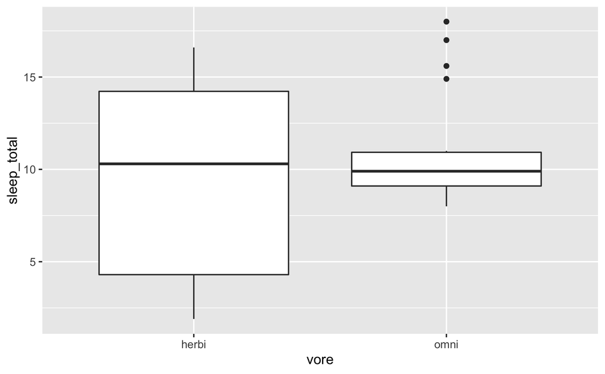

```r
herb_animals %>%
  ggplot()+
  aes(y = sleep_total, x = vore) +
  geom_boxplot()
```

There is agreater spread of herbivores shown in our plot above. The median value however is pretty much the same.

observed stats:

```r
observed_stat <- herb_animals %>%
  specify(sleep_total ~ vore) %>%
  calculate("diff in means", order = c("omni", "herbi"))
```

Null distribution:

```r
null_distribution <- herb_animals %>%
  specify(sleep_total ~ vore) %>%
  hypothesise(null = "independence") %>%
  generate(reps = 10000, type = "permute") %>%
  calculate("diff in means", order = c("omni", "herbi"))
```

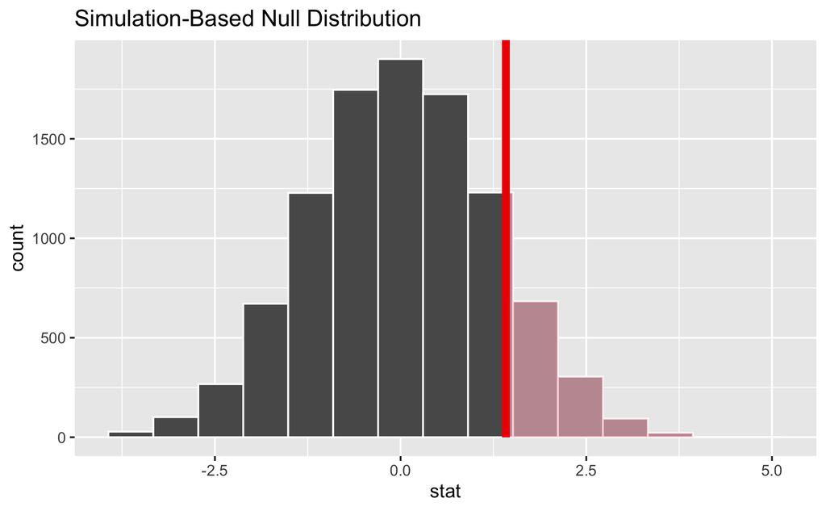

```r
null_distribution %>%
  visualise() +
  shade_p_value(observed_stat, "right")
```

```r
null_distribution %>%
get_p_value(observed_stat, "right")
```

| p_value |
| --- |
| 0.1271 |

The p-value is greater than α value. Therefore we lack evidence to reject our H0 value. There is mot enough eviden ce provides to shpw that the mean value is statisticly signoficantly different between herbivores and omnivores

# Question 3

# Perform an appropriate statistical test to determine whether the proportion of domesticated animal types in the population of animal types is greater than 5%.

H0: πdomesticated = 0.05 Ha: πdomesticated > 0.05

```r
domesticated_animals <- msleep %>%
  mutate(conservation = coalesce(conservation, "not_listed")) %>%
  mutate(is_domesticated = ifelse(conservation == "domesticated", "domesticated", "not_domesticated"))
```

```r
domesticated_animals %>%
  group_by(is_domesticated) %>%
  summarise(prop = n()/ nrow(domesticated_animals))
```

| is_domesticated | prop |
| --- | --- |
| domesticated | 0.1204819 |
| not_domesticated | 0.8795181 |

Calculate null distribution:

```r
null_distribution <- domesticated_animals %>%
  specify(response = is_domesticated, success = "domesticated") %>%
  hypothesise(null = "point", p = 0.05) %>%
  generate(reps = 10000, type = "simulate") %>%
  calculate(stat = "prop")
```

Observed stat:

```r
observed_stat <- domesticated_animals %>%
specify(response = is_domesticated, success = "domesticated") %>%
  calculate(stat = "prop")
observed_stat
```

| stat |
| --- |
| 0.1204819 |

Null distributuion of observed stat:

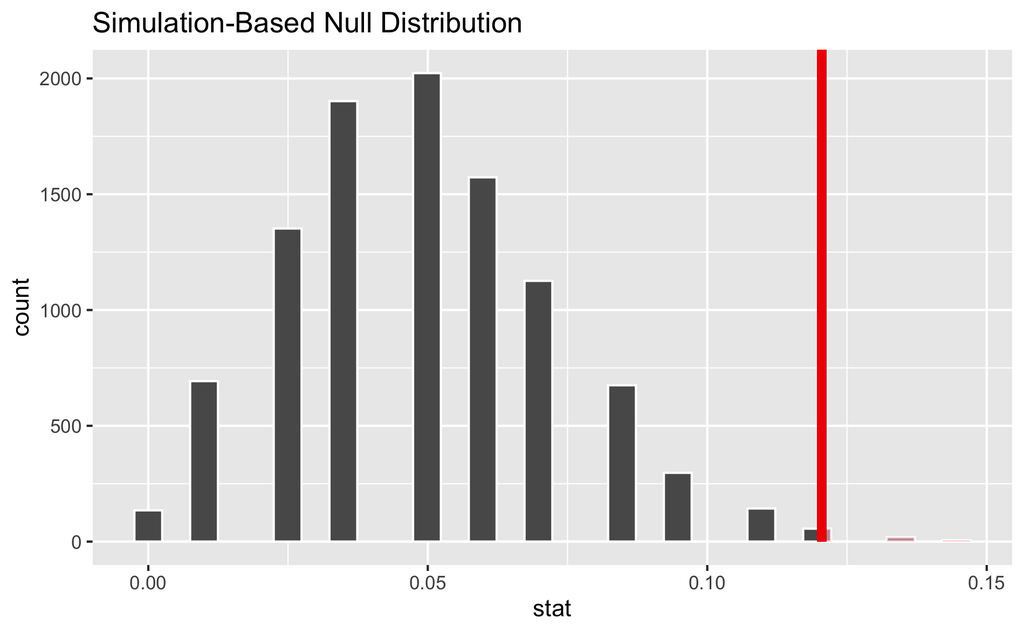

```r
null_distribution %>%
  visualise(bins = 30) +
  shade_p_value(obs_stat = observed_stat, direction = "right")
```

P value

```r
null_distribution %>%
get_p_value(obs_stat = observed_stat, direction = "greater")
```

| p_value |
| --- |
| 0.0081 |

The p-value is less than α we reject H0 in favour of Ha. We found enough evidence to suggest that the sample proportion is statistically significantly greater than the null value.

# Question 1

You work for a independent coffee shop. You’ve performed a small survey in the local town and found that 40% of the people you randomly asked were aware of your shop in the town. You then conduct a marketing campaign by flyering local venues and targeting advertisements on social media. Finally you conduct a second small random survey in the town, asking if people are aware of your coffee shop. You want to test the hypothesis that the campaign has significantly increased awareness of the shop.

H0: πaware_of_shop = 0.40 Ha: πaware_of_shop > 0.40

H0 = the proportion of people aware of the shop = 0.4 Ha = the propprotion of people aware of the shop > 0.4

Because we are using proportion valbues to gather results we are using simulation if data.

### Question 2

You work for a website design company and have performed an A/B test on the position of a banner on a website page promoting a particular item.

In the current test, the first group continues to be shown the banner at the right hand side of the webpage (its usual position) while the test group is shown it at the top of the page. The performance metric we will be testing is click through rate (CTR) on the banner, i.e. what proportion of users click on the banner

Proportions:

H0 pclicks_a - pclicks_B = 0 Ha pclicks_a - pclicks_B < 0

H0 = the proportion of clicks on a - the proportion of clicks on b = 0 Ha the proportion of clicks on a - the proportion of clicks on b < 0

To determine this result we will use permitations becuase we are using more than one sample.

### Question 3

You work as an analyst for a car manufacturing company - they have specific standards they must meet for standards and regulation purposes. You have been asked to check the quality control of the manufacture of a particular car part. The part must have a width of 145mm, with a small (given) level of tolerance. You have been given data on a sample of 1,000 parts produced over the period of a week.

H0:mu_width_part = 145 H1 mu_width_part != 145

H0 mean width of part = 145 Ha mean width of part not equal to 145

since we are working with 1 mean we will be using bootstraping

# Question 1

Coffee shop problem. Significance level: 0.05 calculated p-value: 0.07

the p-value is greater than α then we lack sufficient evidence to reject H0 and so we fail to reject H0.

Based on our sample, we do not have enough evidence that the proportion is statistically significantly greater than the null value.

# Question 2

Website company problem. Significance level: 0.01 p-value: 0.006

The p-value is less than α we reject H0 in favour of Ha. We found enough evidence in the sample to suggest that the sample proportion is statistically significantly less than the null value

# Question 3

Manufacturing company problem. Significance level: 0.05 p-value: 0.55

The p-value is greater than α then we lack sufficient evidence to reject H0 and so we fail to reject H0. Based on our sample, we do not have enough evidence that the mean/proportion is statistically significantly different from the null value.